# Sesión introductoria

# ¿Quién hace esto profesionalmente?

## Roles Orientados a Datos - Data Analyst

[figure not shown]

Fuente: [DataCamp - Data Science Industry Infographic](https://www.datacamp.com/tutorial/data-science-industry-infographic)

## Roles Orientados a Datos - Data Analyst

[figure not shown]

Fuente: LinkedIn

## Roles Orientados a Datos - Data Scientist

[figure not shown]

Fuente: [DataCamp - Data Science Industry Infographic](https://www.datacamp.com/tutorial/data-science-industry-infographic)

## Roles Orientados a Datos - Data Scientist

[figure not shown]

Fuente: LinkedIn

## Roles Orientados a Datos - Data Architect

[figure not shown]

Fuente: [DataCamp - Data Science Industry Infographic](https://www.datacamp.com/tutorial/data-science-industry-infographic)

## Roles Orientados a Datos - Data Engineer

[figure not shown]

Fuente: [DataCamp - Data Science Industry Infographic](https://www.datacamp.com/tutorial/data-science-industry-infographic)

## Remuneración: Inteligencia Artificial

| Posición / Experiencia | 3 a 5 años | 5 a 8 años | 8 a 12 años |
| --- | --- | --- | --- |
| Ingeniero IA | $14M - $18M | $18M - $23M | $23M - $30M |
| Ingeniero de Datos IA | $12M - $16M | $16M - $23M | $23M - $32M |
| Ingeniero LLM | — | $15M - $23M | $23M - $30M |
| Ingeniero IA Agéntico | $12M - $15M | $15M - $18M | $18M - $26M |
| Founding AI Engineer | — | — | $25M - $35M |
| Chief AI Officer | — | — | $50M - $65M |

Fuente: [Michael Page - Guía Salarial](https://www.michaelpage.com.co/guia-salarial/gracias-profesionales?#introtablesbox)

## Remuneración: Data & Analytics

| Posición / Experiencia | 3 a 5 años | 5 a 8 años | 8 a 12 años |
| --- | --- | --- | --- |
| Data Engineer | $12M - $18M | $18M - $23M | $23M - $28M |
| Data Scientist | $10.5M - $14M | $14M - $18M | $18M - $24M |
| BI (Business Intelligence) | $9M - $13M | $13M - $16M | $16M - $22.7M |
| Arquitecto de Datos | $14.5M - $17M | $17M - $24M | $24M - $30M |
| RPA (Robotic Process Automation) | $11M - $15M | $15M - $22.7M | $22.7M - $25M |

Fuente: [Michael Page - Guía Salarial](https://www.michaelpage.com.co/guia-salarial/gracias-profesionales?#introtablesbox)

## Consolidación: El Valor del Rol de Datos

¿Por qué es tan cotizado este perfil?

- 📈 **Alto ROI:** Un modelo productivo puede generar o ahorrar millones a la empresa.
- 🧩 **Multidisciplina:** Cruce escaso de Matemáticas, Programación y Negocio.
- 🌐 **Escasez:** La velocidad de adopción supera ampliamente la oferta calificada.

# ¿Con qué herramientas lo haremos?

## Popularidad de los lenguajes de programación

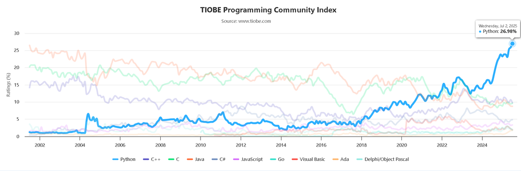

Fuente: [TIOBE Index](https://www.tiobe.com/tiobe-index/)

## Sklearn y Problemas de ML

[figure not shown]

Fuente: [Scikit-Learn Machine Learning Map](https://scikit-learn.org/stable/tutorial/machine_learning_map/index.html)

## Herramientas Sugeridas

- ☁️ **Google Colab:** Entorno de Python en la nube.
- 🧠 **Google Gemini:** Asistente IA para programar.
- ⚙️ **N8N:** Automatización de flujos de trabajo.

## Google Colab

Ambiente de desarrollo en Python o R para el análisis de datos. Permite la ejecución en la nube de programas, con una cantidad generosa de recursos.

[figure not shown]

## Google Colab con Gemini

Cuenta con el chat de Gemini embebido en el ambiente de desarrollo. Asiste en la escritura de código.

[figure not shown]

## Análisis Exploratorio de Datos

**Prompt**: Haz un analisis exploratorio de datos del archivo de github datasciencedojo titanic.csv usando la librería ydata-profiling. Instala la ultima version disponible de la libreria.

[figure not shown]

## Análisis Exploratorio de Datos

**Prompt**: Haz un analisis exploratorio de datos del archivo de github datasciencedojo titanic.csv usando la librería ydata-profiling. Instala la ultima version disponible de la libreria.

[figure not shown]

# ¿Y la responsabilidad?

## La pregunta ética

Si un modelo de ML decide **negar un crédito**, **rechazar un CV**, o **diagnosticar un cáncer** erróneamente… - ¿Quién es responsable si se equivoca? ¿El programador/a? ¿La empresa? ¿El modelo?

💬 **Discusión:** Analicemos en detalle las implicaciones de la responsabilidad ética en sistemas automatizados.

## Ética y Responsabilidad

La responsabilidad en Inteligencia Artificial requiere un enfoque claro:

- ⚖️ **Responsabilidad (Accountability):** La entidad responde ante la ley (supervisión humana).
- 🔍 **Explicabilidad (Explainability):** Justificar razonadamente cómo y por qué decide el modelo.
- 🛡️ **Mitigación de Sesgos (Fairness):** Evitar discriminar injustamente por datos históricos.
- 🇪🇺 **Regulación:** Leyes modernas (como el AI Act de la UE) según el nivel de riesgo del sistema.

## Libros - Ética en IA

[figure not shown]

[figure not shown]

[figure not shown]

# ¿Qué van a lograr en este curso?

## Objetivos de Formación

- **Herramientas Prácticas:** Brindar herramientas de Machine Learning para el desarrollo de soluciones a problemas reales.
- **Desarrollo de Habilidades:** Aplicar conceptos fundamentales para fortalecer la capacidad de abstracción y la resolución de problemas.
- **Conciencia Crítica:** Generar reflexión sobre el impacto social y las implicaciones éticas del Machine Learning.

## Resultados de Aprendizaje

Al finalizar el curso, el estudiante podrá:

- **Resolver Problemas:** Aplicar principios de Machine Learning para solucionar problemas en su campo profesional.
- **Validar Soluciones:** Diseñar experimentos para evaluar la efectividad de las soluciones implementadas.
- **Actuar con Ética:** Discutir y aplicar la responsabilidad ética y social en el uso de la tecnología, fomentando el autoaprendizaje.

## References

Géron, Aurélien. 2022. *Hands-on Machine Learning with Scikit-Learn, Keras, and TensorFlow: Concepts, Tools, and Techniques to Build Intelligent Systems*. 3rd ed. O’Reilly Media, Inc.

Russell, Stuart J., and Peter Norvig. 2020. *Artificial Intelligence: A Modern Approach*. 4th ed. Pearson.